# Coursework Report

*N* removed NAs: 3

*N* removed typo: 1

*N* removed <18: 19

*N* total clean: 127

| Group | *N* | *M*<sub>age</sub> | *M*<sub>rating</sub> |
| --- | --- | --- | --- |
| Control | 60 | 20.87 | 4.99 |
| Experim | 67 | 20.37 | 6.61 |

**Main analysis results**

*t*(125) = -11.25, *p* < .001

[interactive chart not shown]

[figure not shown]

[interactive chart not shown]

# Coursework Report

Analysing Data, Spring 2020

# Methods

## Participants

This study contained 150 participants. The mean age of participants was 20.6 (Range 18-28), and the standard deviation of the age was 2.02. 20 participants’ data was removed, 19 because they were under the age of 18, and 1 because the age entered was ‘2y’ and due to ethical issues we had to remove it because of not knowing the true age of the participant. As well as this 3 other participants were removed because of missing data in the Age columns, so once again was removed due to ethical issues. Therefore, overall 127 participants’ data was used in the end.

Table 1 *Descriptive statistics by Group and Age*

| Group | *N* | % | *M*<sub>age</sub> | *SD*<sub>age</sub> |
| --- | --- | --- | --- | --- |
| White | 60 | 47.24 | 20.87 | 1.95 |
| Red | 67 | 52.76 | 20.37 | 2.06 |

## Design

In this research we are looking to see what influences women’s attraction to men and if the red effect is replicable. Perceived attractiveness was assessed with three face items/questions: “How attractive do you think this person is?” “How pleasant is this person to look at?” and “If I were to meet the person in this picture face to face, I would think he is attractive.” (Elliott et al., 2010, pg. 403.) These items were assessed on a rating scale of 1-9, 1 being not attractive at all and 9 being extremely attractive, and the scores were averaged to form a composite score. We examined the hypothesis that the colour red increases women’s attraction to men and does so by increasing the woman’s perception of status, which increases her attraction to him. The statistical analysis used to test it, is the T-Test, as we are testing the difference between two means - the colour Red and the colour White.

# Results

We wanted to know whether there was a relationship between the colour red and the perceived attractiveness of men. A composite score was created by gathering the average results for each participant across the three questions and created a mean and then grouping it into the two conditions. Then we conducted a T-Test on the influence of colour condition, to test the difference between the two means, of the red condition and the white condition. The t-test revealed that there was a significant colour effect (*M*<sub>diff</sub> = -1.62, 95% CI [-1.9, -1.33], *t* (125) = -11.25, *p* = 0) (See Figure 1). White condition participants had an average total score of (*M* = 4.99), whereas Red condition participants had an average total score of (*M* = 6.61). This means that, as predicted, since there was a higher score on average of the three questions with the red condition, it indicates more of an attraction by the women to the men with the background colour of red, therefore, the female participants felt more of an attraction to the man in the red than the white.

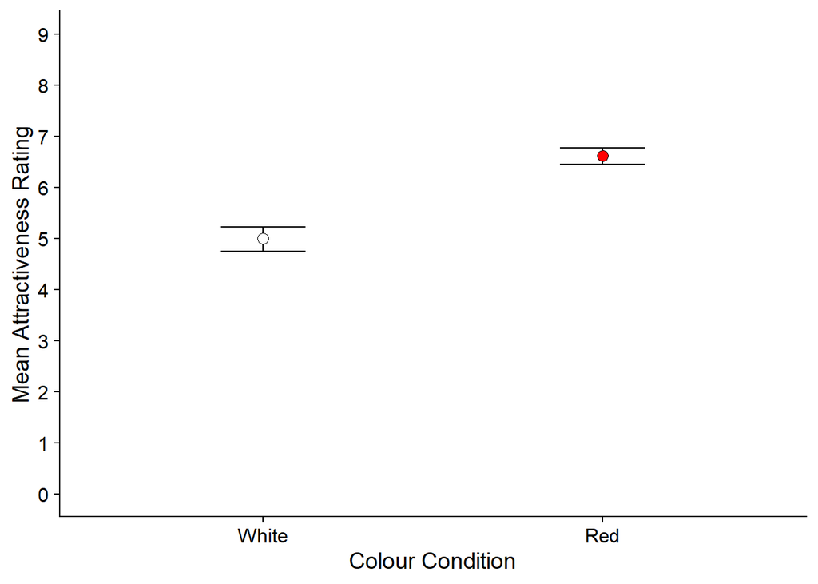

**Figure 1.** *A graph to show Perceived Attractiveness in relation to Colour (+/- 1 SEM)*

# Discussion

This experiment was done to see what influences women’s attraction to men, in particular whether the colour red enhanced women’s attraction to men. The replication attempt supported the hypothesised red effect as there was found to be a significant difference with the two colour conditions. On average there was a higher score over the three questions on perceived attraction to men with the background colour of red than there was with the control colour of white, therefore, the female participants felt more of an attraction to the man in the red than the white.

Elliot et al., (2010) found a significant colour effect on perceived attraction, those in the red condition , compared with those in the red, rated the man as more attractive. This follows the same pattern of results as from our experiment, both having a significant effect, supporting the hypothesis. It can further be strengthened by a study done by Wen et al., (2014) which found that men with masculine facial cues and wearing the colour red were perceived by females as more sexually attractive. This is due to the link between masculinity (Boothroyd, Jones, Burt and Perrett, 2007) and red both being signals of status in males, where females tend to favour men with status. Further supporting our link to the colour effect in attraction and also introducing a look into the link of sexual dimorphism as being a factor that helps attraction further with the colour red.

On the other hand there has been a look into the publication bias of Elliott’s findings, Francis (2013) discussed how after doing an analysis of the results, there is not enough evidence to support the claims made, ‘the probability that the 12 findings would all reject the null hypothesis is only .005’. Therefore, reducing the integrity of his findings. This is further supported by a replication study of Elliott et al.’s (2010) study, which found that neither of their replications yielded a statistically significant effect of the colour red on perceived attractiveness (Hesslinger, V.M., Goldbach, L. & Carbon, C, 2015). The red effect can be also be looked at as being negative, too much of the colour red can be seen to be aggressive, and reduce attraction in men’s faces (Stephen, I. D., et al., 2012). Suggesting that the colour effect found from Elliott’s findings may not be as robust as thought.

In this particular experiment, there are some strengths. In the original study (Elliott et al., 2010) only twenty one participants were used, whereas in our data, there were 127 participants data used, making our results more representable. As well as this, it was a laboratory experiment, meaning it was done in a controlled setting, so there was a control on extraneous variables that could have affected the results, also allowing for a cause and effect relationship to be established. Finally, our findings have not only supported our hypothesis, but they have also further supported the findings by Elliott (2010), due to our results showing significant difference between the red and white conditions, this further improves the external reliability of the colour effect theory we are testing for.

On the other hand, there are also limitations to the study. Despite taking place in a lab, this can raise the issue of ecological validity. For example, people may react differently in a real-life situation, there could be more dominating factors such as ethnicity, or apparel style (Hill, Nocks, Gardner., 1987) that could outweigh the colour effect, so it is difficult to draw on the conclusion that these reactions would be the same in a natural environmental setting. However, because of the fact it was a lab experiment means there was great control of extraneous variables, meaning we are able to establish more of a cause and effect relationship with the colour effect and the perceived attractiveness. Leading on from this, there is the issue of diversity among the pictures, the experiment only used a picture of one Caucasian male, therefore, this may have affected how women from different ethnic groups rated the attractiveness of the man, it is unable to know the true effect of the colour effect, without having the knowledge of other factors that could influence the effect. Because we didn’t take the information of the ethnicity of the participants themselves, we are unable to know if the data is generalisable to different cultures or if it is a representative sample. But, the fact of only using one person can be seen to be positive, as there will always be individual differences in attraction preferences. By having a Caucasian male, which some may not prefer, will help see if the colour red truly does make them more attractive, which would in fact help the colour effect suggested by Elliott.

Overall, our replication study did in fact support the findings that men are perceived to be more attractive to women in conjunction with the colour red but due to the bias in Elliott et al., (2010) findings and contradictory findings with no colour effect, it is hard to say whether the colour effect is significant enough. Therefore, further research needs to be done in order to help strengthen or dismiss the theory. For example, there needs to be a further look into ethnicity, in future studies, there should be a baseline study, where the participants are given a larger sample of diverse people in order to control for idiosyncrasies. This can be demonstrated by a recent study by Young (2015) the participants were provided with 40 pictures (a larger sample), to look at the influence of baseline attractiveness. The colour effect emerged for female faces who were rated as attractive beforehand but not for those who were rated as unattractive. This could then be tried with men to look at the influence of baseline attractiveness, to see if it increases the red effect.

Another aspect that can be looked at for further research is that of age and ovulation. One of the pieces of information we collected was the age of the participants, but we didn’t look at it in a way that might have been beneficial. In particular in that of the ovulatory cycle, it has been found that there is a link between cyclical shifts and preferences for physical male traits, for example, ‘regularly cycling and, pregnant women showed a stronger preference for masculinity than lactating and post-menopausal women’ (Marcinkowska, U. M., Jasienska, G., & Prokop, P., 2018). This therefore, raises the question of whether the ovulation cycle of women has more of an impact over attraction of men than the colour red. Moreover, it has been found that in some species of vertebrae, both males and females have a change in sensitivity to red when they are in their reproductive period (Boulcott & Braithwaite, 2007). This raises the question, of the sensitivity of women to the changes in males colouration (Cole, G. L. and J. A. Endler., 2018) during their cycles, and whether it can have an impact on their perceived attractiveness of men. So, for future research there should be a look into cycle status and age as to whether they can change women’s inclination towards men and in particular, their link to the colour red, and whether all of these factors combined could have a significant part in the colour effect.

In conclusion, the colour red has been found in many non-human species and humans to link to attraction, sex, passion and love, in particular, with women, but in this research it has been found that this link can also be applied to the perceived attractiveness of men. There has been found to be some contradictory findings with the link to men, but with other dominating factors such as masculinity and reproductive states, there is an increase when also paired with the colour red in the right instance. Further research needs to be done, particularly with the diversity of the participants, in order to generalise the findings to different ethnicities and cultures, or to see whether or not it is a significant enough effect in the perceived attractiveness of men.

# References

Boothroyd, L. G., Jones, B. C., Burt, D. M., and Perrett, D. I. (2007). Partner characteristics associated with masculinity, health and maturity in male faces. *Personality and Individual Differences, 43,* 1161–1173.

Boulcott, P., & Braithwaite, V. A. (2007). Color perception in three-spined sticklebacks: Sexes are not so different after all. Evolutionary Ecology, 21, 601–611. Cole, G. L. and J. A. Endler (2018). “Change in male coloration associated with artificial selection on foraging colour preference.” *J Evol Biol 31* (8): 1227-1238.

Elliot, A. J., Kayser, D. N., Greitemeyer, T., Lichtenfeld, S., Gramzow, R. H., Maier, M. A., & Liu, H. . (2010). Red, rank, and romance in women viewing men. . *Journal of Experimental Psychology: General,, 139,* 399-417.

Francis, G. (2013). Publication bias in “Red, rank, and romance in women viewing men,” by elliot et al. (2010). *Journal of Experimental Psychology: General, 142*(1), 292-296. doi:http://dx.doi.org/10.1037/a0027923

Hesslinger, V.M., Goldbach, L. & Carbon, C. (2015) Men in red: A reexamination of the red-attractiveness effect. *Psychon Bull Rev 22,* 1142–1148. https://doi.org/10.3758/s13423-015-0866-8

Hill, E. M., Nocks, E. S., & Gardner, L. (1987). Physical attractiveness: Manipulation by physique and status

displays. *Ethology and Sociobiology, 8* (2), 143–154. doi:10.1016/0162-3095(87)90037-9

Marcinkowska, U. M., Jasienska, G., & Prokop, P. (2018). A Comparison of Masculinity Facial Preference Among Naturally Cycling, Pregnant, Lactating, and Post-Menopausal Women. *Archives of sexual behavior, 47* (5), 1367–1374.https://doi.org/10.1007/s10508-017-1093-3

Stephen, I. D., et al. (2012). “Redness enhances perceived aggression, dominance and attractiveness in men’s faces.” *Evol Psychol 10* (3): 562-572.

Wen, F., Zuo, B., Wu, Y., Sun, S., & Liu, K. (2014). Red is Romantic, but Only for Feminine Females: Sexual Dimorphism Moderates Red Effect on Sexual Attraction. *Evolutionary Psychology.* https://doi.org/10.1177/147470491401200404

Young, S. G. (2015). The effect of red on male perceptions of female attractiveness: Moderation by baseline attractiveness of female faces. *European Journal of Social Psychology, 45,* 146–151. doi:10.1002/ejsp.2098